# working with text with `stringr`

Author

Casey Schine adapted from Violet Ross

```r
#LOAD PACKAGES
library(tidyverse)
library(stringr)
```

## A few basics

**What is a string?**

A string is a data type used to represent text. In R, we indicate that something is a string by referring to it with quotes.

Examples of strings:

- Rwanda
- #11111
- 1w3r
- 1999_1

NOT a string:

- 1999

**What is** `stringr` **?**

stringr is a package containing a bunch of functions that help us work with strings.

[**stringr cheat sheet**](https://evoldyn.gitlab.io/evomics-2018/ref-sheets/R_strings.pdf)

# Using `stringr`

**I’m registering for classes for this Fall and am trying to decide which courses to take.**

Let’s look at the course catalog!

Read in the courses data.

```r
# Download the courses.csv dataset

# you will need to put in your own filepath here
# !!!!!!!!!!!!!!!!!!!!!!!!!!!!!!!!!!!!!!!!!!!!!!!!!!!!!!!
courses <- read_csv("~/Dropbox/!Middlebury/Teaching/STAT 118/S2026/S2026_R_Proj/data/courses.csv")
# !!!!!!!!!!!!!!!!!!!!!!!!!!!!!!!!!!!!!!!!!!!!!!!!!!!!!!!

view(courses)
```

## `str_detect`

**inputs**:

- a string (or a column of strings) to search *from*
- a string to search *for*

**output**: boolean value (TRUE or FALSE)

little example:

```r
# using str_detect to search for strings
# for the string "Welcome to data science, look at this cool data"

#find the pattern "data"
str_detect("Welcome to data science, look at this cool data", "data")
```

```
[1] TRUE
```

```r
# find the pattern "pineapple"
str_detect("Welcome to data science, look at this cool data", "pineapple")
```

```
[1] FALSE
```

```r
# note for me to look into
# can you do this for a whole dataset??? analog for the lookfor function in Stata

# to select columns that contain a specific string:
courses |>
select(contains("course"))
```

```
# A tibble: 568 × 1
   courseNum
   <chr>
 1 AMST0121A-F25
 2 AMST0175A-F25
 3 AMST0213A-F25
 4 AMST0231A-F25
 5 AMST0253A-F25
 6 AMST0257A-F25
 7 AMST0273A-F25
 8 AMST0281A-F25
 9 AMST0287A-F25
10 AMST0343A-F25
# ℹ 558 more rows
```

```r
# you can also use ends_with(), starts_with(), and matches()


# this code will filter for all rows that contain the pattern "CHEM" no matter where it appears
courses |>
  filter(if_any(everything(), ~str_detect(.x, "CHEM")))
```

```
# A tibble: 19 × 9
   titles      distros department time  location professor description courseNum
   <chr>       <chr>   <chr>      <chr> <chr>    <chr>     <chr>       <chr>
 1 Molecular … SCI     Biology    11:1… "McCard… Erin Egg… "\nMolecul… BIOL0365…
 2 Foundation… <NA>    Chemistry… 9:45… "McCard… Rick Bunt "\nCHEM 01… CHEM0102…
 3 General Ch… DED SCI Chemistry… 9:45… "McCard… AJ Vasil… "\nIn this… CHEM0104…
 4 General Ch… DED SCI Chemistry… 8:40… "McCard… Alex Bre… "\nIn this… CHEM0105…
 5 Organic Ch… SCI     Chemistry… 11:1… "McCard… Rick Bunt "\nIn this… CHEM0205…
 6 Organic Ch… SCI     Chemistry… 9:45… "McCard… Thomas A… "\nIn this… CHEM0205…
 7 Foundation… DED SCI Chemistry… 8:15… "McCard… Kira Rahn "\nIn this… CHEM0211…
 8 Foundation… SCI     Chemistry… 9:45… "McCard… Alex Bre… "\nThis co… CHEM0231…
 9 Organic Ch… <NA>    Chemistry… 8:15… "McCard… Thomas A… "\nIn this… CHEM0305…
10 Organic Ch… <NA>    Chemistry… 9:45… "McCard… Lindsay … "\nIn this… CHEM0305…
11 Biochemist… <NA>    Chemistry… 9:45… "McCard… Emma Gui… "\nThis co… CHEM0322…
12 Biochemist… <NA>    Chemistry… 11:1… "McCard… <NA>      "\nThis co… CHEM0322…
13 Seminar in… <NA>    Chemistry… 11:1… "McCard… Lindsay … "\nThis se… CHEM0400…
14 Instrument… CW      Chemistry… 11:1… "McCard… Kira Rah… "\nIn this… CHEM0411…
15 Biochemist… <NA>    Chemistry… 9:45… "McCard… Emma Gui… "\nA livin… CHEM0425…
16 Quantum Ch… <NA>    Chemistry… 2:15… "McCard… AJ Vasil… "\nIn this… CHEM0455…
17 Environmen… SCI     Earth & C… 9:45… "McCard… Peter Ry… "\nThis co… ECSC0323…
18 Environmen… SCI     Prog in E… 11:1… "McCard… Kate Cra… "\nIn this… ENVS0230…
19 Mapping Gl… DED     Geography  11:1… "McCard… Jeff How… "(formerly… GEOG0251…
# ℹ 1 more variable: meet <chr>
```

I only want to take classes in Warner! Let’s filter for rows where we **detect** the word “Warner” in the `location` column.

```r
# filter for where the location column contains the pattern "WNS"

courses |>
  distinct(location) |>
  pull()
```

```
  [1] "Wright Memorial Theater SEM (WTH SEM)\n"
  [2] "Axinn Center 219 (AXN 219)\n"
  [3] "Axinn Center 104 (AXN 104)\n"
  [4] "Axinn Center 220 (AXN 220)\n"
  [5] "Axinn Center 229 (AXN 229)\n"
  [6] "Munroe Hall 311 (MNR 311)\n"
  [7] "Munroe Hall 409 (MNR 409)\n"
  [8] "Munroe Hall 217 (MNR 217)\n"
  [9] "Munroe Hall 317 (MNR 317)\n"
 [10] "Mahaney Center for the Arts 125 (MAC 125)\n"
 [11] "Library 230 (LIB 230)\n"
 [12] "Freeman CK2 (FIC CK2)\n"
 [13] "Munroe Hall 401 (MNR 401)\n"
 [14] "Mahaney Center for the Arts 232 (MAC 232)\n"
 [15] "Johnson Memorial Building 103 (JHN 103)\n"
```

[output cut: 88 more lines]

```r
warner_classes <- courses |>
  filter(str_detect(location, "WNS"))

warner_classes
```

```
# A tibble: 48 × 9
   titles      distros department time  location professor description courseNum
   <chr>       <chr>   <chr>      <chr> <chr>    <chr>     <chr>       <chr>
 1 Beginning … LNG     Chinese    8:40… "Warner… Hang Du … "\nThis co… CHNS0101…
 2 Beginning … LNG     Chinese    9:45… "Warner… Hang Du … "\nThis co… CHNS0101…
 3 Economic S… DED     Economics  12:4… "Warner… Erick Go… "\nAn intr… ECON0111…
 4 Introducto… SOC     Economics  9:45… "Warner… David Mu… "\nAn intr… ECON0150…
 5 Introducto… SOC     Economics  11:1… "Warner… David Mu… "\nAn intr… ECON0150…
 6 Introducto… SOC     Economics  8:15… "Warner… Cihan Ar… "\nAn intr… ECON0150…
 7 Introducto… SOC     Economics  2:15… "Warner… <NA>      "\nAn intr… ECON0150…
 8 Introducto… SOC     Economics  2:15… "Warner… Phani Wu… "\nAn intr… ECON0155…
 9 Introducti… DED     Economics  9:45… "Warner… German R… "\nIn this… ECON0211…
10 Introducti… DED     Economics  11:1… "Warner… German R… "\nIn this… ECON0211…
# ℹ 38 more rows
# ℹ 1 more variable: meet <chr>
```

```r
# look at what str_detect actually outputs in column
warner_classes <- courses |>
  mutate(loc_boolean=str_detect(location, "WNS"))

warner_classes
```

```
# A tibble: 568 × 10
   titles      distros department time  location professor description courseNum
   <chr>       <chr>   <chr>      <chr> <chr>    <chr>     <chr>       <chr>
 1 Cultural C… <NA>    Program i… 2:15… "Wright… Olga San… "\nIn this… AMST0121…
 2 Immigrant … AMR HIS Program i… 11:1… "Axinn … Rachael … "\nIn this… AMST0175…
 3 Introducti… AMR HI… Program i… 7:30… "Axinn … Roberto … "\nIn this… AMST0213…
 4 See the U.… AMR CW… Program i… 11:1… "Axinn … Deb Evans "\nIn this… AMST0231…
 5 Science Fi… LIT     Program i… 2:15… "Axinn … Michael … "\nTime tr… AMST0253…
 6 Music and … CMP LIT Program i… 9:45… "Axinn … William … "\nAlthoug… AMST0257…
 7 <NA>        AMR AR… Program i… 9:45… "Axinn … Ellery F…  <NA>       AMST0273…
 8 Viewer Dis… AMR AR… Program i… 2:15… "Axinn … Ellery F… "\nWhat ar… AMST0281…
 9 Posthuman … LIT     Program i… 11:1… "Axinn … Michael … "\nMedical… AMST0287…
10 Humanitari… AMR     Program i… 12:4… "Axinn … Rachael … "\nThis pu… AMST0343…
# ℹ 558 more rows
# ℹ 2 more variables: meet <chr>, loc_boolean <lgl>
```

Suppose I don’t want any classes on Friday. Let’s use `str_detect` to find our options.

```r
# look for instances of the pattern "Friday" in the meet column
# using str_detect()
# filter them out

nofriday_classes <- courses |>
  filter(!str_detect(meet, "Friday"))

nofriday_classes
```

```
# A tibble: 461 × 9
   titles      distros department time  location professor description courseNum
   <chr>       <chr>   <chr>      <chr> <chr>    <chr>     <chr>       <chr>
 1 Cultural C… <NA>    Program i… 2:15… "Wright… Olga San… "\nIn this… AMST0121…
 2 Immigrant … AMR HIS Program i… 11:1… "Axinn … Rachael … "\nIn this… AMST0175…
 3 Introducti… AMR HI… Program i… 7:30… "Axinn … Roberto … "\nIn this… AMST0213…
 4 See the U.… AMR CW… Program i… 11:1… "Axinn … Deb Evans "\nIn this… AMST0231…
 5 Science Fi… LIT     Program i… 2:15… "Axinn … Michael … "\nTime tr… AMST0253…
 6 Music and … CMP LIT Program i… 9:45… "Axinn … William … "\nAlthoug… AMST0257…
 7 <NA>        AMR AR… Program i… 9:45… "Axinn … Ellery F…  <NA>       AMST0273…
 8 Viewer Dis… AMR AR… Program i… 2:15… "Axinn … Ellery F… "\nWhat ar… AMST0281…
 9 Posthuman … LIT     Program i… 11:1… "Axinn … Michael … "\nMedical… AMST0287…
10 Humanitari… AMR     Program i… 12:4… "Axinn … Rachael … "\nThis pu… AMST0343…
# ℹ 451 more rows
# ℹ 1 more variable: meet <chr>
```

```r
# we can do the same thing using the negate argument in str_detect
nofriday_classes <- courses |>
  filter(str_detect(meet, "Friday", negate=TRUE))

nofriday_classes
```

```
# A tibble: 461 × 9
   titles      distros department time  location professor description courseNum
   <chr>       <chr>   <chr>      <chr> <chr>    <chr>     <chr>       <chr>
 1 Cultural C… <NA>    Program i… 2:15… "Wright… Olga San… "\nIn this… AMST0121…
 2 Immigrant … AMR HIS Program i… 11:1… "Axinn … Rachael … "\nIn this… AMST0175…
 3 Introducti… AMR HI… Program i… 7:30… "Axinn … Roberto … "\nIn this… AMST0213…
 4 See the U.… AMR CW… Program i… 11:1… "Axinn … Deb Evans "\nIn this… AMST0231…
 5 Science Fi… LIT     Program i… 2:15… "Axinn … Michael … "\nTime tr… AMST0253…
 6 Music and … CMP LIT Program i… 9:45… "Axinn … William … "\nAlthoug… AMST0257…
 7 <NA>        AMR AR… Program i… 9:45… "Axinn … Ellery F…  <NA>       AMST0273…
 8 Viewer Dis… AMR AR… Program i… 2:15… "Axinn … Ellery F… "\nWhat ar… AMST0281…
 9 Posthuman … LIT     Program i… 11:1… "Axinn … Michael … "\nMedical… AMST0287…
10 Humanitari… AMR     Program i… 12:4… "Axinn … Rachael … "\nThis pu… AMST0343…
# ℹ 451 more rows
# ℹ 1 more variable: meet <chr>
```

```r
# this doesn't work because the string is not an exact match due to difference in case
nofriday_classes <- courses |>
  filter(!str_detect(meet, "friday"))
```

Perhaps I’m interested in immigration. We can use `str_detect` to find course descriptions that mention immigration.

The `regex` function is used to write regular expressions in R. Regular expressions are helpful if you want to search for a pattern rather than a specific word or phrase.  
For now, we will only use regex to ignore capitalization. If you’re interested in using regular expressions at some point, this [regex cheat sheet](https://cheatography.com/davechild/cheat-sheets/regular-expressions/) will be super helpful.

```r
# filter for class descriptions that contain the pattern "immigration" using str_detect()
# use regex to ignore upper versus lower case as: regex("immigration", ignore_case=TRUE)

immigration_courses <- courses |>
  filter(str_detect(description, regex("immigration", ignore_case=TRUE)))

immigration_courses
```

```
# A tibble: 7 × 9
  titles distros department time  location professor description courseNum meet
  <chr>  <chr>   <chr>      <chr> <chr>    <chr>     <chr>       <chr>     <chr>
1 Immig… AMR HIS Program i… 11:1… "Axinn … Rachael … "\nIn this… AMST0175… "Tue…
2 Globa… AMR NOR Economics  12:4… "Axinn … Erin Wol… "\nDoes gl… ECON0420… "Tue…
3 Intro… CMP     Internati… 11:1… "Twilig… Amit Pra… "\nThis is… IGST0101… "Tue…
4 An In… EUR LN… Italian    9:45… "Atwate… Thomas V… "\nIntende… ITAL0251… "Fri…
5 An In… EUR LN… Italian    11:1… "Atwate… Pat Zupan "\nIntende… ITAL0251… "Fri…
6 Globa… SOC     Political… 9:45… "Hillcr… Orion Le… "\nHow doe… PSCI0314… "Tue…
7 Chris… AMR HI… Religion   1:30… "Munroe… James Ca… "\nReligio… RELI0398… "Wed…
```

## `str_extract` and `str_remove`

**str_extract inputs**:

- a string (or a column of strings) to extract *from*
- a string to extract

**str_extract output**: the string you wanted to extract OR nothing

**str_remove inputs**:

- a string (or a column of strings) to remove stuff *from*
- a string to remove

**str_remove output**: the first input string with the second input removed

little example:

```r
# for the string "Welcome to data science, look at this cool data"
# and the pattern "data"

# str_extract() extracts first instance
str_extract("Welcome to data science, look at this cool data", "data")
```

```
[1] "data"
```

```r
# str_extract_all() extracts all instances
str_extract_all("Welcome to data science, look at this cool data", "data")
```

```
[[1]]
[1] "data" "data"
```

```r
# str_remove() removes first instance
str_remove("Welcome to data science, look at this cool data", "data")
```

```
[1] "Welcome to  science, look at this cool data"
```

```r
# str_remove_all() removes all instances
str_remove_all("Welcome to data science, look at this cool data", "data")
```

```
[1] "Welcome to  science, look at this cool "
```

CW is part of the distribution requirement column. I want CW to be its own column.  
First we can create a new column called `isCW` by **extracting** instances of “CW” from the `distros` column in each row.  
Then we can **remove** all instances of “CW” from the `distros` column.

```r
# make new column that states whether a course is CW or not
# and count how many classes are CW

courses_CW <- courses |>
  mutate(isCW = str_extract(distros, "CW"))

courses_CW
```

```
# A tibble: 568 × 10
   titles      distros department time  location professor description courseNum
   <chr>       <chr>   <chr>      <chr> <chr>    <chr>     <chr>       <chr>
 1 Cultural C… <NA>    Program i… 2:15… "Wright… Olga San… "\nIn this… AMST0121…
 2 Immigrant … AMR HIS Program i… 11:1… "Axinn … Rachael … "\nIn this… AMST0175…
 3 Introducti… AMR HI… Program i… 7:30… "Axinn … Roberto … "\nIn this… AMST0213…
 4 See the U.… AMR CW… Program i… 11:1… "Axinn … Deb Evans "\nIn this… AMST0231…
 5 Science Fi… LIT     Program i… 2:15… "Axinn … Michael … "\nTime tr… AMST0253…
 6 Music and … CMP LIT Program i… 9:45… "Axinn … William … "\nAlthoug… AMST0257…
 7 <NA>        AMR AR… Program i… 9:45… "Axinn … Ellery F…  <NA>       AMST0273…
 8 Viewer Dis… AMR AR… Program i… 2:15… "Axinn … Ellery F… "\nWhat ar… AMST0281…
 9 Posthuman … LIT     Program i… 11:1… "Axinn … Michael … "\nMedical… AMST0287…
10 Humanitari… AMR     Program i… 12:4… "Axinn … Rachael … "\nThis pu… AMST0343…
# ℹ 558 more rows
# ℹ 2 more variables: meet <chr>, isCW <chr>
```

```r
# now make a new column for distros and remove CW using str_remove()
courses_CW <- courses |>
  mutate(isCW = str_extract(distros, "CW")) |>
  mutate(distros = str_remove(distros, "CW"))

courses_CW
```

```
# A tibble: 568 × 10
   titles      distros department time  location professor description courseNum
   <chr>       <chr>   <chr>      <chr> <chr>    <chr>     <chr>       <chr>
 1 Cultural C… <NA>    Program i… 2:15… "Wright… Olga San… "\nIn this… AMST0121…
 2 Immigrant … AMR HIS Program i… 11:1… "Axinn … Rachael … "\nIn this… AMST0175…
 3 Introducti… AMR HI… Program i… 7:30… "Axinn … Roberto … "\nIn this… AMST0213…
 4 See the U.… AMR  H… Program i… 11:1… "Axinn … Deb Evans "\nIn this… AMST0231…
 5 Science Fi… LIT     Program i… 2:15… "Axinn … Michael … "\nTime tr… AMST0253…
 6 Music and … CMP LIT Program i… 9:45… "Axinn … William … "\nAlthoug… AMST0257…
 7 <NA>        AMR AR… Program i… 9:45… "Axinn … Ellery F…  <NA>       AMST0273…
 8 Viewer Dis… AMR AR… Program i… 2:15… "Axinn … Ellery F… "\nWhat ar… AMST0281…
 9 Posthuman … LIT     Program i… 11:1… "Axinn … Michael … "\nMedical… AMST0287…
10 Humanitari… AMR     Program i… 12:4… "Axinn … Rachael … "\nThis pu… AMST0343…
# ℹ 558 more rows
# ℹ 2 more variables: meet <chr>, isCW <chr>
```

```r
# count the number of CW courses
courses_CW |>
  count(isCW)
```

```
# A tibble: 2 × 2
  isCW      n
  <chr> <int>
1 CW       71
2 <NA>    497
```

## `str_sub`

**str_sub inputs**:

- a string (or a column of strings) take substrings of
- where the substring should start
- where the substring should end

**str_sub output**: the substring

little example:

```r
#extract the pieces of a string using str_sub() function
# extract the substring data science
# from the sentence "Welcome to data science, look at this cool data"
# need to define the position of the start character and the end character

str_sub("Welcome to data science, look at this cool data",
        start=12, end=23)
```

```
[1] "data science"
```

```r
# move the start and end to extract a different string
# the default end is the end of the string
str_sub("Welcome to data science, look at this cool data",
        start=39)
```

```
[1] "cool data"
```

Maybe I only want 200 level math and stats classes.  
First we filter for just math/stats classes. Then we can create a new column called `level` that contains only the sixth character from the `courses` column.

We can then filter our `level` column for specific course levels.

```r
# first let's get all of the exact department names
courses |>
  distinct(department) |>
  pull()
```

```
 [1] "Program in American Studies"    "Anthropology"
 [3] "Arabic"                         "Arts Division"
 [5] "Program in Studio Art"          "Biology"
 [7] "Program in Black Studies"       "Chemistry & Biochemistry"
 [9] "Chinese"                        "Classics"
[11] "Comparative Literature"         "English"
[13] "English & American Literatures" "Computer Science"
[15] "Dance"                          "Economics"
[17] "Earth & Climate Sciences"       "Education Studies"
[19] "Prog in Environmental Studies"  "Film & Media Culture"
[21] "History"                        "Food Studies"
[23] "French"                         "First-Year Seminar Program"
[25] "Geography"                      "Global Health"
[27] "German"                         "PrgGender/Sexuality/Fem. Study"
[29] "History of Art & Architecture"  "Modern Hebrew"
[31] "International & Global Studies" "Interdepartmental"
[33] "Prog in Int'l Politics & Econ"  "Italian"
[35] "Japanese Studies"               "Jewish Studies"
[37] "Program in Literary Studies"    "Linguistics"
[39] "Mathematics & Statistics"       "Mathematics"
[41] "Music"                          "Prog in Neuroscience"
[43] "Spanish (& Portuguese UG)"      "Philosophy"
[45] "Physics"                        "Political Science"
[47] "Psychology"                     "Religion"
[49] "Russian"                        "Sociology"
[51] "Luso-Hispanic Studies"          "Theatre"
[53] "Writing and Rhetoric Program"   "bleh"
```

```r
# mutate on a column called level that extracts the 6th character from courseNum column

Math_200 <- courses |>
  filter(str_detect(department, "Mathematics")) |>
  mutate(level=str_sub(courseNum , start=6, end=6)) |>
  filter(level==2) #filter for level 2 only

Math_200
```

```
# A tibble: 10 × 10
   titles      distros department time  location professor description courseNum
   <chr>       <chr>   <chr>      <chr> <chr>    <chr>     <chr>       <chr>
 1 Linear Alg… DED     Mathemati… 8:40… "Warner… Jennifer… "\nMatrice… MATH0200…
 2 Linear Alg… DED     Mathemati… 9:45… "Warner… Jennifer… "\nMatrice… MATH0200…
 3 Linear Alg… DED     Mathemati… 11:1… "Warner… Bill Pet… "\nMatrice… MATH0200…
 4 Linear Alg… DED     Mathemati… 1:10… "Warner… Bill Pet… "\nMatrice… MATH0200…
 5 Multivaria… DED     Mathemati… 8:40… "Warner… John Sch… "\nThe cal… MATH0223…
 6 Multivaria… DED     Mathemati… 1:10… "Giffor… Evan Cam… "\nThe cal… MATH0223…
 7 <NA>        DED     Mathemati… 11:1… "McCard… Noah Gra…  <NA>       MATH0226…
 8 Introducti… DED     Mathemati… 8:15… "Warner… Becky Ta… "\nAn intr… STAT0201…
 9 Introducti… DED     Mathemati… 11:1… "Warner… Meaghan … "\nAn intr… STAT0201…
10 Statistica… DED     Mathemati… 11:1… "75 Sha… Christia… "(formerly… STAT0218…
# ℹ 2 more variables: meet <chr>, level <chr>
```

```r
# filter for 200 level classes without mutating first

Math_200 <- courses |>
  filter(str_detect(department, "Mathematics")) |>
  filter(str_sub(courseNum, start=6, end=6)==2)

Math_200
```

```
# A tibble: 10 × 9
   titles      distros department time  location professor description courseNum
   <chr>       <chr>   <chr>      <chr> <chr>    <chr>     <chr>       <chr>
 1 Linear Alg… DED     Mathemati… 8:40… "Warner… Jennifer… "\nMatrice… MATH0200…
 2 Linear Alg… DED     Mathemati… 9:45… "Warner… Jennifer… "\nMatrice… MATH0200…
 3 Linear Alg… DED     Mathemati… 11:1… "Warner… Bill Pet… "\nMatrice… MATH0200…
 4 Linear Alg… DED     Mathemati… 1:10… "Warner… Bill Pet… "\nMatrice… MATH0200…
 5 Multivaria… DED     Mathemati… 8:40… "Warner… John Sch… "\nThe cal… MATH0223…
 6 Multivaria… DED     Mathemati… 1:10… "Giffor… Evan Cam… "\nThe cal… MATH0223…
 7 <NA>        DED     Mathemati… 11:1… "McCard… Noah Gra…  <NA>       MATH0226…
 8 Introducti… DED     Mathemati… 8:15… "Warner… Becky Ta… "\nAn intr… STAT0201…
 9 Introducti… DED     Mathemati… 11:1… "Warner… Meaghan … "\nAn intr… STAT0201…
10 Statistica… DED     Mathemati… 11:1… "75 Sha… Christia… "(formerly… STAT0218…
# ℹ 1 more variable: meet <chr>
```

## `str_count`

**str_count inputs**:

- a string (or a column of strings) to count *from*
- a string you want to count the number of instances of

**str_count output**: the number of times the second string occurs in your first string

little example:

```r
# count the instance of the word "data" in the sentence "Welcome to data science, look at this cool data"
# using str_count()

str_count("Welcome to data science, look at this cool data", "data")
```

```
[1] 2
```

```r
str_count("Welcome to data science, look at this cool data", "look")
```

```
[1] 1
```

Maybe I only want my classes to meet twice a week. Let’s **count** how many times “day” appears in the `meet` column and put this value in a new column called `day_count`. `day_count` represents how many days a week a class meets.

```r
# mutate on a column called day_count using str_count() for the meet column, looking for instances of the string "day"

# save day_count as a column

course_days <- courses |>
  mutate(day_count=(str_count(meet, "day")))


# now extract what is the max number of days a class meets

course_days |>
  summarize(max_days=max(day_count)) |>
  pull()
```

```
[1] 6
```

```r
# which courses meet 6 days a week
course_days |>
  filter(day_count==6)
```

```
# A tibble: 2 × 10
  titles distros department time  location professor description courseNum meet
  <chr>  <chr>   <chr>      <chr> <chr>    <chr>     <chr>       <chr>     <chr>
1 Fall … ART     Theatre    7:30… "Mahane… Michole … "\nThe cas… THEA0210… Mond…
2 Fall … ART     Theatre    7:30… "Wright… Olga San… "\nThe cas… THEA0210… Mond…
# ℹ 1 more variable: day_count <int>
```

Let’s visualize this data.

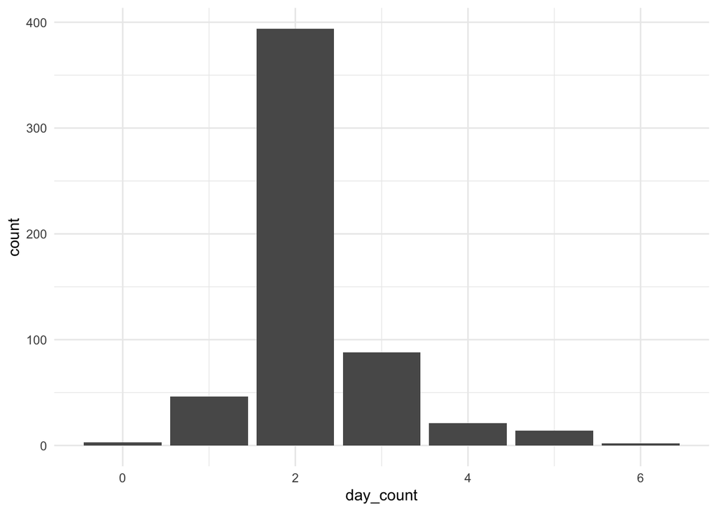

```r
# make a bar plot of dayCount with x=day_count

course_days |>
  ggplot() +
  geom_bar(aes(x=day_count)) +
  theme_minimal()
```

## `word`

Allows you to select words from a string. The function assumes as a default that the words are separated by a space, but you can define a different separator if you need using the `sep=` argument.

```r
# let's look at the help docs
#?word


word("Welcome to data science, look at this cool data", 3)
```

```
[1] "data"
```

```r
# mutate new column called building with just the first word from location

course_building <- courses |>
  mutate(building = word(location, start=1, end=2))
```

Let’s make a plot using some of the columns we’ve just made:

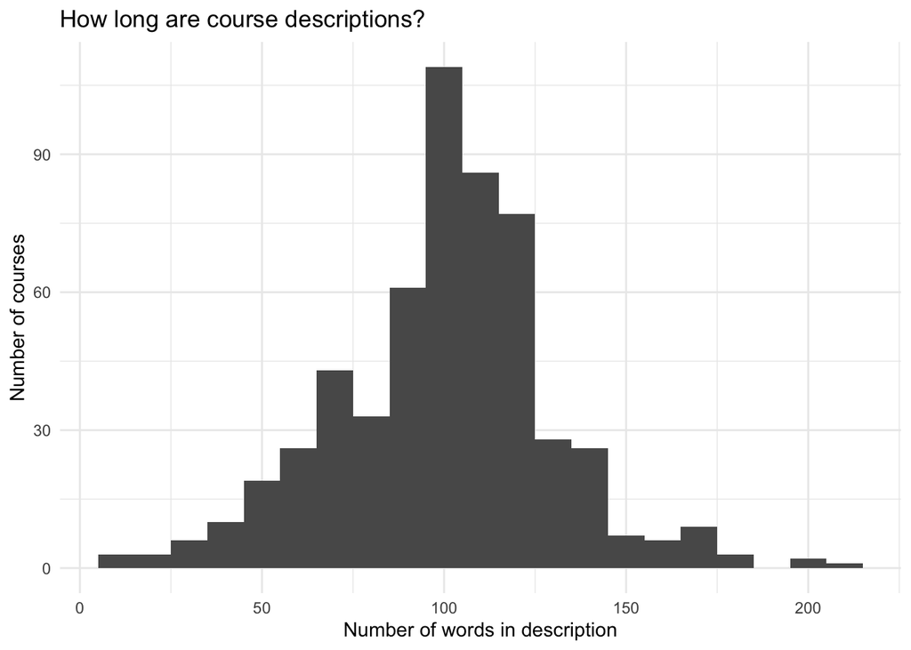

```r
# what should we plot???

# count the number of words in the description
# we do this by counting the number of spaces and then adding 1
course_description <- courses |>
  mutate(desc_words = str_count(description, pattern=" ") + 1)

course_description |>
  ggplot(aes(x = desc_words)) +
  geom_histogram(binwidth = 10) +
  theme_minimal() +
  labs(
    x = "Number of words in description",
    y = "Number of courses",
    title = "How long are course descriptions?"
  )
```

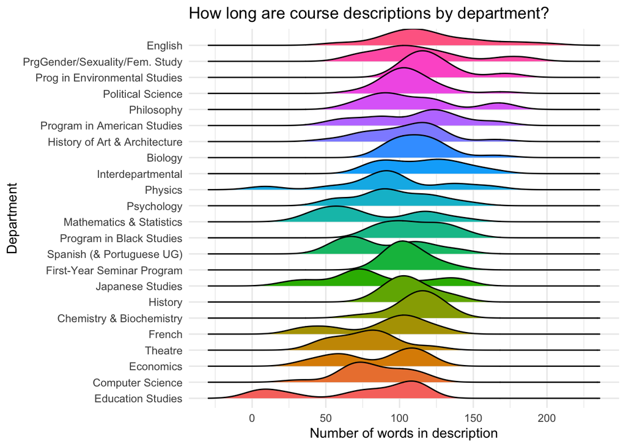

```r
# Now I'm wondering which courses have the longest descriptions
course_description |>
  filter(desc_words>150) |>
  view()

# Now I want to know how the word count distribution changes by department
library(ggridges)

course_description |>
  mutate(department=factor(department),
         department=fct_lump_min(department,10),
         department=fct_reorder(department, desc_words, .fun=max)) |>
  filter(department != "Other") |>
  ggplot(aes(x = desc_words, y = department)) +
  geom_density_ridges(aes(fill=department)) +
  theme_minimal() +
  labs(x = "Number of words in description",
       y = "Department",
       title = "How long are course descriptions by department?") +
  theme(legend.position = "none")
```

```r
# I had to stop myself here
```

## In groups

Make a bar plot with the number of classes that meet in each building. Put the building name on the y-axis and the number of classes that meet there on the x-axis. Put the y-axis in order from the building with the most classes to the building with the least classes. It doesn’t have to be perfect. With more time and for a more polished plot there are things you would do to clean it up. This is about combining some of the tools you just learned with some that you learned throughout the semester.

```r
# mutate column called building with first 2 words from location

course_building <- courses |>
  mutate(building = factor(word(location, start=1, end=2)))

course_building
```

```
# A tibble: 568 × 10
   titles      distros department time  location professor description courseNum
   <chr>       <chr>   <chr>      <chr> <chr>    <chr>     <chr>       <chr>
 1 Cultural C… <NA>    Program i… 2:15… "Wright… Olga San… "\nIn this… AMST0121…
 2 Immigrant … AMR HIS Program i… 11:1… "Axinn … Rachael … "\nIn this… AMST0175…
 3 Introducti… AMR HI… Program i… 7:30… "Axinn … Roberto … "\nIn this… AMST0213…
 4 See the U.… AMR CW… Program i… 11:1… "Axinn … Deb Evans "\nIn this… AMST0231…
 5 Science Fi… LIT     Program i… 2:15… "Axinn … Michael … "\nTime tr… AMST0253…
 6 Music and … CMP LIT Program i… 9:45… "Axinn … William … "\nAlthoug… AMST0257…
 7 <NA>        AMR AR… Program i… 9:45… "Axinn … Ellery F…  <NA>       AMST0273…
 8 Viewer Dis… AMR AR… Program i… 2:15… "Axinn … Ellery F… "\nWhat ar… AMST0281…
 9 Posthuman … LIT     Program i… 11:1… "Axinn … Michael … "\nMedical… AMST0287…
10 Humanitari… AMR     Program i… 12:4… "Axinn … Rachael … "\nThis pu… AMST0343…
# ℹ 558 more rows
# ℹ 2 more variables: meet <chr>, building <fct>
```

```r
course_building |>
  filter(location=="bleh")
```

```
# A tibble: 2 × 10
  titles distros department time  location professor description courseNum meet
  <chr>  <chr>   <chr>      <chr> <chr>    <chr>     <chr>       <chr>     <chr>
1 bleh   bleh    bleh       <NA>  bleh     bleh      "Cultural … AMST0121… bleh
2 bleh   bleh    bleh       <NA>  bleh     bleh      "Cultural … AMST0121… bleh
# ℹ 1 more variable: building <fct>
```

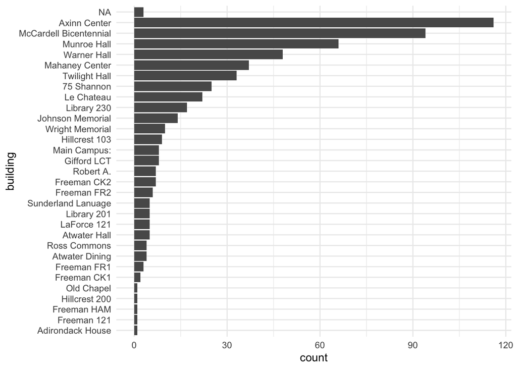

```r
# make bar plot of the number of classes by building

course_building |>
  group_by(building) |>
  summarize(count=n()) |>
  mutate(building=fct_reorder(building, count)) |>
  ggplot() +
  geom_col(aes(y=building, x=count)) +
  theme_minimal()
```